# Class_Survey_aa2569

aa2569@scarletmail.rutgers.edu

4/17/2023

## Loading the Dataset

```r
library(readr)
library(MVA)
```

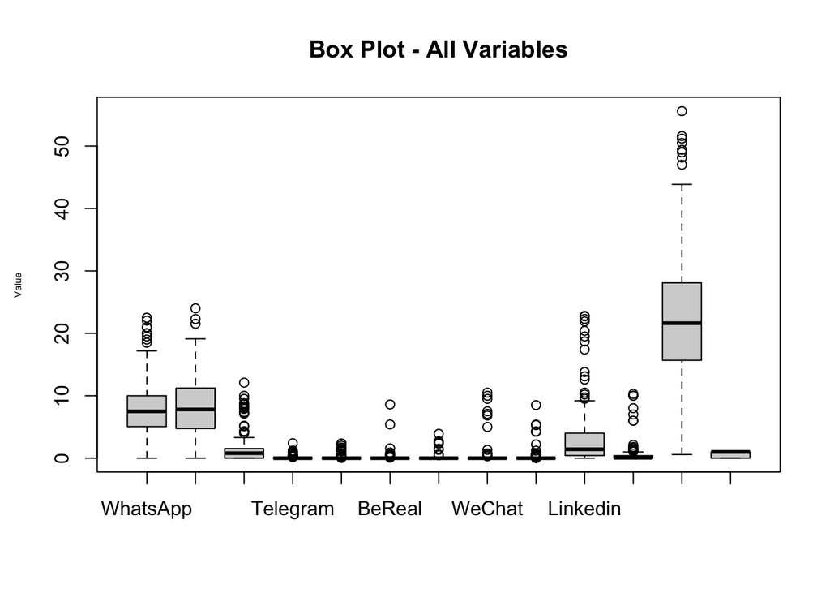

```r
library(HSAUR2)
library(SciViews)
library(scatterplot3d)
library(car)
library(lattice)
library(GGally)
library(ggplot2)
library(ggridges)
library(ggvis)
library(ggthemes)
library(cowplot)
library(gapminder)
library(gganimate)
library(dplyr)
library(tidyverse)
library(grid)
library(gridExtra)
library(RColorBrewer)
library(Hotelling)
library(stats)
library(biotools)
library(factoextra)
library(FactoMineR)
library(ggfortify)
library(psych)
library(corrplot)
library(devtools)
library(cluster)
library(magrittr)
library(NbClust)
library(MASS)
library(gvlma)
library(leaps)
library(relaimpo)
library(e1071)
library(pROC)
library(memisc)
library(ROCR)
library(klaR)
library(caret)
library(caTools)

sm_data <- read.csv("/Users/ajayvishnu/Desktop/RUTGERS/Spring_2023/Multivariate Analysis/Datasets/Class_Survey.csv")

sm <- sm_data[,c(3:15)]

boxplot(sm, main = "Box Plot - All Variables", ylab = "Value", par(cex.lab = 0.5))
```

```r
sm_new <- sm_data[,c(3,4,5,12,14,15)]
```

### Two Approaches

- As we have many outliers, we can try to analyse the data in two different methods and check if there is any difference.
- We can consider two approaches - One considering all the Data, One considering only the columns WhatsApp, Instagram, Snapchat, LinkedIn, Total Social Media hours, and Addiction.

## QUESTIONS and HYPOTHESIS

### Questions

#### Based on the given variables, can we classify if the student is addicted to Social Media or not?

#### Based on the given variables, can we predict if the student is addicted to Social Media or not?

### Hypothesis

#### We can predict if the student is addicted to social media based on the time they have spent of the individual social media apps.

## Analysing the Data

```r
str(sm)
```

```
## 'data.frame':    175 obs. of  13 variables:
##  $ WhatsApp                      : num  8.9 11.8 12.2 12.3 8.5 ...
##  $ Instagram                     : num  7.1 11.2 16.8 12.9 11.9 ...
##  $ Snapchat                      : num  1.9 2.45 3.25 3.12 1.9 1.2 1.67 2 1.4 2.1 ...
##  $ Telegram                      : num  0.02 0.06 0.01 0.06 0.05 0.16 0 0.25 0.35 0.33 ...
##  $ Facebook.Messenger            : num  0 0 0 0 0 0 0 0 0 0 ...
##  $ BeReal                        : num  0 0 0 0 0 0 0 0.35 0.21 0.65 ...
##  $ TikTok                        : num  0 0 0 0 0 0 0 0 0 0 ...
##  $ WeChat                        : num  0 0 0 0 0 0 0 0 0 0 ...
##  $ Twitter                       : num  0 0 0 0 0 0 0 0 0 0 ...
##  $ Linkedin                      : num  4.5 5.5 9.5 9 7.5 8 6.5 2.5 2.67 1.55 ...
##  $ Messages                      : num  0.1 0.04 0.01 0.2 0.1 0.01 0 0.2 0.8 0.5 ...
##  $ Total.Social.Media.Screen.Time: num  22.5 31.1 41.8 37.6 29.9 ...
##  $ Social.Media.Addiction        : int  1 1 1 1 1 1 1 1 1 1 ...
```

- We have converted the Addiction column (column 15) to 1 and 0 - 1 being Addicted and 0 being not addicted.
- This will be used for the prediction model that we built.

### Data Dictionary

- Student - Name of the Student
- Week - Week start and end date
- Whatsapp - Time spent on Whatsapp per week(hrs)
- Instagram - Time spent on Instagram per week(hrs)
- Snapchat - Time spent on Snapchat per week(hrs)
- Telegram - Time spent on Telegram per week(hrs)
- Facebook/Messenger - Time spent on Facebook/Messenger per week(hrs)
- BeReal - Time spent on BeReal per week(hrs)
- TikTok - Time spent on Tiktok per week(hrs)
- Wechat - Time spent on WeChat per week(hrs)
- Twitter - Time spent on Twitter per week(hrs)
- Linkedin - Time spent on LinkedIn per week(hrs)
- Messages - Time spent on Messages per week(hrs)
- Total Social Media Screen Time - Total time spent on social media per week(hrs)
- Social Media Addiction Level - Is the person addicted to social media?  
  # Times opened >= 105 - Addicted # Times opened < 105 - Not Addicted # Considering the 24-hour slots in a day, how many hour slots did the user open social media apps? This is for one day. # Consider the above count and add the daily counts over the week and input that data

### Correlation Test

#### Main Dataset

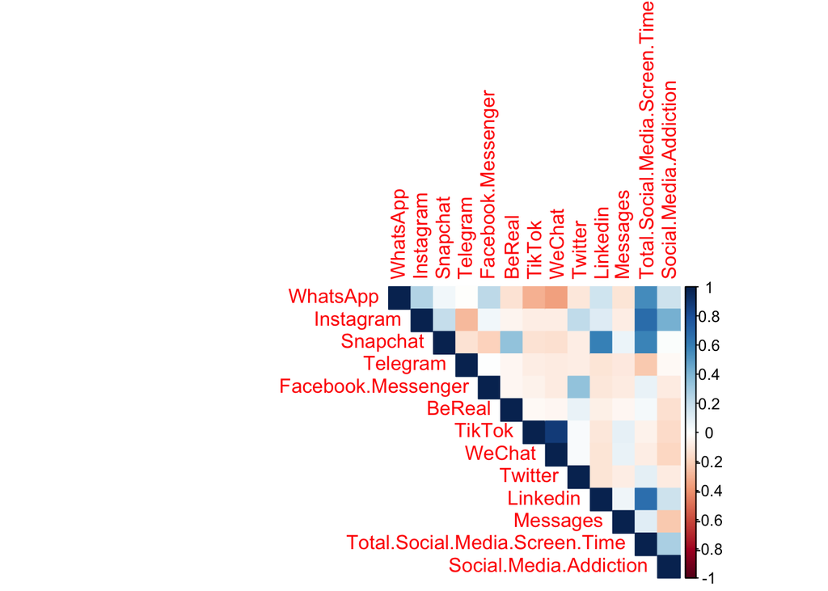

```r
corrplot(cor(sm), type = "upper", method = "color")
```

#### New Dataset

[figure not shown]

```r
corrplot(cor(sm_new), type = "upper", method = "color")
```

- The correlation matrix shows us that there is correlation between the columns in both cases.
- Hence, Principal Component Analysis (PCA) can be used to reduce the number of columns for the analysis.

## Principal Component Analysis (PCA)

###PCA

```r
sm_pca <- prcomp(sm[,1:11],scale=TRUE)
sm_new_pca <- prcomp(sm_new[,-6],scale=TRUE)
```

- We have excluded the last column which is the addiction (Addicted/Not addicted) as we are trying answer the question on how to classify the students.

### Scree diagram

#### Main Dataset

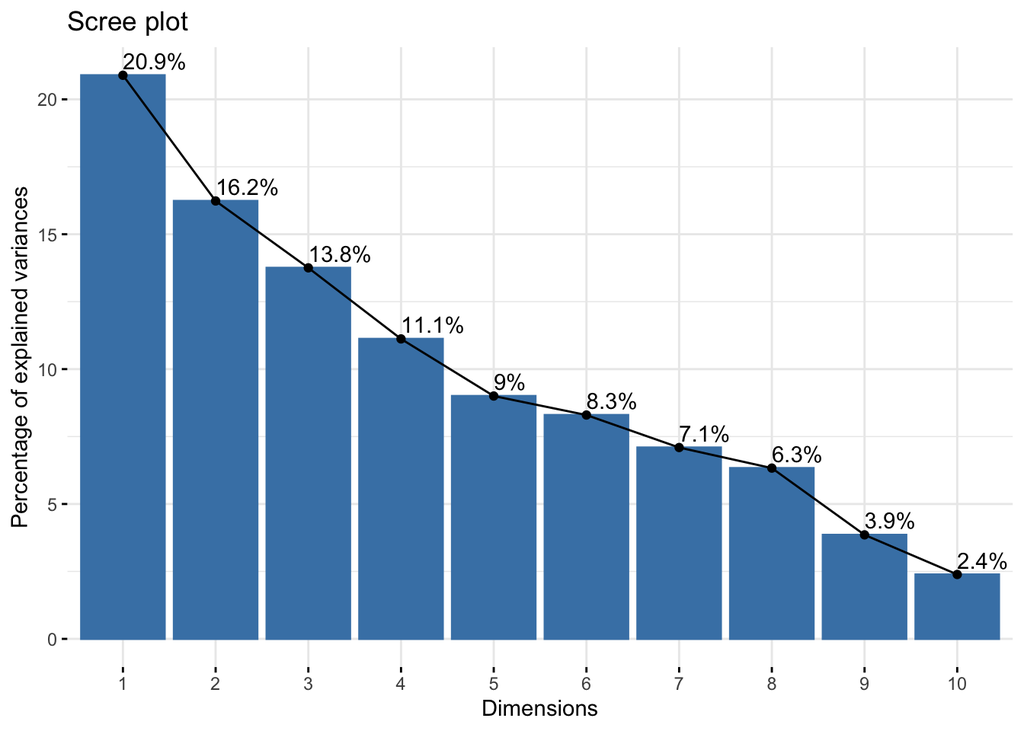

```r
fviz_eig(sm_pca, addlabels = TRUE)
```

- The scree diagram shows us that sum of the first 2 principal components is less than 70%.
- So, we cannot move forward using PCA for column reduction.
- We now move on to check EFA for this main dataset.

#### New Dataset

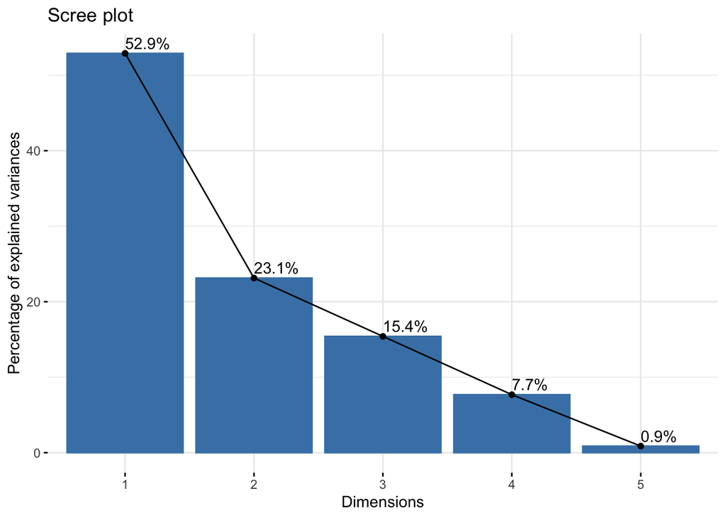

```r
fviz_eig(sm_new_pca, addlabels = TRUE)
```

- The scree diagram shows us that sum of the first 2 principal components is 76%.
- So, we can use PCA for column reduction.
- No need to consider EFA for this approach as there are already less columns (5) in this dataset.

##### PCA Values (New Dataset)

```r
pca_data <- as.data.frame(sm_new_pca$x)
pca_data <- pca_data[,1:2]
```

- We can use this dataset for our cluster analysis later for this approach.

## Exploratory Factor Analysis (EFA)

### EFA

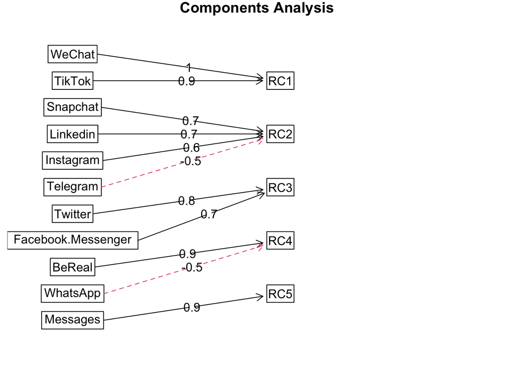

```r
fit.sm <- principal(sm[,1:11], nfactors=5, rotate="varimax")
fa.diagram(fit.sm)
```

### Defining the factors obtained

#### RC1

- Both WeChat and Tiktok are popular apps in Asia region specifically.
- WeChat has multiple uses for chatting, payments, whereas Tiktok is used only for social media purpose to share and view videos.

#### RC2

- Snapchat, LinkedIn, Instagram, Telegram are popular all over the world.
- LinkedIn is used for professional purposes. Snapchat, Telegram are used for chatting and Instagram is used for posting photos and videos.

#### RC3

- Twitter & Facebook are popular all over the world.
- Both are used for posting photos and videos.

#### RC4

- WhatsApp is popular world wide and BeReal is a new app that has entered the social media market.

#### RC5

- RC5 has only one variable pertaining to it.
- So, we excluding the RC5 and consider the Messages column directly.

### Defining new columns through EFA

```r
efa_data <- as.data.frame(fit.sm$scores)
efa_data <- efa_data[,-5]
efa_data$C5 <- sm$Messages..hrs.
```

## Clustering

### Kmeans optimal clusters

- As we have two factors, Addicted and Not Addicted, we check the clustering for 2 clusters only.

#### Main Dataset

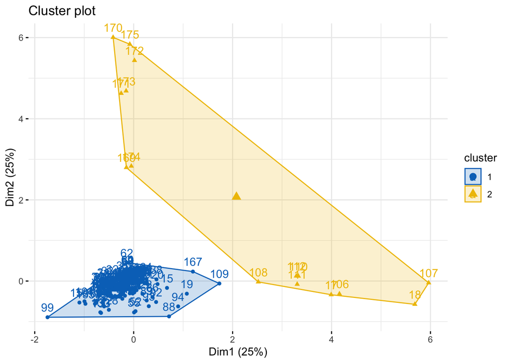

```r
set.seed(42)
matstd_sm <- scale(efa_data)

km.res <- kmeans(matstd_sm, 2, nstart = 10)

fviz_cluster(km.res, data = matstd_sm,
             ellipse.type = "convex",
             palette = "jco",
             ggtheme = theme_minimal())
```

- We have used the efa_data for the clustering of the forst approach.
- We can check the precision and recall using the confusion matrix below.

```r
Clustered <- ifelse(km.res$cluster > 1.5, "Not Addicted", "Addicted")
Actual <- ifelse(sm$Social.Media.Addiction == 1, "Addicted", "Not Addicted")
confusion_mat <- table(Clustered, Actual)
confusion_mat
```

```
##               Actual
## Clustered      Addicted Not Addicted
##   Addicted           97           63
##   Not Addicted        3           12
```

```r
accuracy <- sum(diag(confusion_mat)) / sum(confusion_mat)
precision <- confusion_mat[2, 2] / sum(confusion_mat[, 2])
recall <- confusion_mat[2, 2] / sum(confusion_mat[2, ])
cat("Accuracy:", round(accuracy, 3), "\n")
```

```
## Accuracy: 0.623
```

```r
cat("Precision:", round(precision, 3), "\n")
```

```
## Precision: 0.16
```

```r
cat("Recall:", round(recall, 3), "\n")
```

```
## Recall: 0.8
```

#### New Dataset

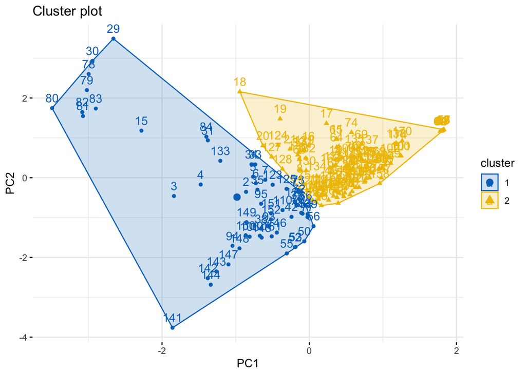

```r
set.seed(42)
matstd_sm1 <- scale(pca_data)

km.res1 <- kmeans(matstd_sm1, 2, nstart = 10)

fviz_cluster(km.res1, data = matstd_sm1,
             ellipse.type = "convex",
             palette = "jco",
             ggtheme = theme_minimal())
```

```r
Clustered1 <- ifelse(km.res1$cluster > 1.5, "Not Addicted", "Addicted")
Actual <- ifelse(sm$Social.Media.Addiction == 1, "Addicted", "Not Addicted")
confusion_mat1 <- table(Clustered1, Actual)
confusion_mat1
```

```
##               Actual
## Clustered1     Addicted Not Addicted
##   Addicted           45           15
##   Not Addicted       55           60
```

```r
accuracy1 <- sum(diag(confusion_mat1)) / sum(confusion_mat1)
precision1 <- confusion_mat1[2, 2] / sum(confusion_mat1[, 2])
recall1 <- confusion_mat1[2, 2] / sum(confusion_mat1[2, ])
cat("Accuracy:", round(accuracy1, 3), "\n")
```

```
## Accuracy: 0.6
```

```r
cat("Precision:", round(precision1, 3), "\n")
```

```
## Precision: 0.8
```

```r
cat("Recall:", round(recall1, 3), "\n")
```

```
## Recall: 0.522
```

- The precision is obtained to be 80% which is not so bad.
- Yet, we see that 55 inputs who are addicted to social media have been clustered to not addicted.
- This shows that we cannot classify our data into Addicted and Not addicted based on the variables given.

## Classification Summary

#### Considering both the approaches, we can see that we cannot classify the data into addicted and not addicted.

#### Answer to our question 1: No, we cannot classify.

## Logistic Regression

- To answer our question 2, we perform logistic regression as we have only 2 variable factors (Addicted/Not Addicted)

```r
str(sm)
```

```
## 'data.frame':    175 obs. of  13 variables:
##  $ WhatsApp                      : num  8.9 11.8 12.2 12.3 8.5 ...
##  $ Instagram                     : num  7.1 11.2 16.8 12.9 11.9 ...
##  $ Snapchat                      : num  1.9 2.45 3.25 3.12 1.9 1.2 1.67 2 1.4 2.1 ...
##  $ Telegram                      : num  0.02 0.06 0.01 0.06 0.05 0.16 0 0.25 0.35 0.33 ...
##  $ Facebook.Messenger            : num  0 0 0 0 0 0 0 0 0 0 ...
##  $ BeReal                        : num  0 0 0 0 0 0 0 0.35 0.21 0.65 ...
##  $ TikTok                        : num  0 0 0 0 0 0 0 0 0 0 ...
##  $ WeChat                        : num  0 0 0 0 0 0 0 0 0 0 ...
##  $ Twitter                       : num  0 0 0 0 0 0 0 0 0 0 ...
##  $ Linkedin                      : num  4.5 5.5 9.5 9 7.5 8 6.5 2.5 2.67 1.55 ...
##  $ Messages                      : num  0.1 0.04 0.01 0.2 0.1 0.01 0 0.2 0.8 0.5 ...
##  $ Total.Social.Media.Screen.Time: num  22.5 31.1 41.8 37.6 29.9 ...
##  $ Social.Media.Addiction        : int  1 1 1 1 1 1 1 1 1 1 ...
```

#### Main Dataset

##### Training and Testing

```r
set.seed(123)
split = sample.split(sm$Social.Media.Addiction, SplitRatio = 0.70)
train_sm = subset(sm, split == TRUE)
test_sm = subset(sm, split == FALSE)

Xtrain_sm <- train_sm[,1:11]
Ytrain_sm <- train_sm[,13]

Xtest_sm <- test_sm[,1:11]
```

- We consider the training and testing data with a 70-30 split.

##### Regression

```r
x_sm <- cbind(Xtrain_sm,Ytrain_sm)
logistic_sm <- glm(Ytrain_sm ~ ., data = x_sm,family='binomial')
summary(logistic_sm)
```

```
##
## Call:
## glm(formula = Ytrain_sm ~ ., family = "binomial", data = x_sm)
##
## Deviance Residuals:
##     Min       1Q   Median       3Q      Max
## -2.9232  -0.8199   0.2994   0.7769   1.7039
##
## Coefficients:
##                    Estimate Std. Error z value Pr(>|z|)
## (Intercept)        -0.98716    0.63774  -1.548   0.1216
## WhatsApp           -0.01881    0.05413  -0.348   0.7282
## Instagram           0.27012    0.06763   3.994  6.5e-05 ***
## Snapchat           -0.36162    0.17298  -2.090   0.0366 *
## Telegram            0.37880    0.68887   0.550   0.5824
## Facebook.Messenger -0.82205    0.55113  -1.492   0.1358
## BeReal             -0.21339    0.78789  -0.271   0.7865
## TikTok              0.26279    1.02170   0.257   0.7970
## WeChat             -0.23816    0.31745  -0.750   0.4531
## Twitter            -0.41172    0.20916  -1.968   0.0490 *
## Linkedin            0.16061    0.07702   2.085   0.0370 *
## Messages           -0.46549    0.20845  -2.233   0.0255 *
## ---
## Signif. codes:  0 '***' 0.001 '**' 0.01 '*' 0.05 '.' 0.1 ' ' 1
##
## (Dispersion parameter for binomial family taken to be 1)
##
##     Null deviance: 166.46  on 121  degrees of freedom
## Residual deviance: 120.46  on 110  degrees of freedom
## AIC: 144.46
##
## Number of Fisher Scoring iterations: 5
```

- The regression summary shows that we have significant variables that affect the output variable.
- We check the confusion matrix, precision and recall of our regression below.

##### Confusion Matrix, Precision

```r
probabilities_sm2 <- predict(logistic_sm, newdata = Xtest_sm, type = "response")

predicted_sm2 <- ifelse(probabilities_sm2 > 0.5, "Yes", "No")
actual_sm <- ifelse(test_sm$Social.Media.Addiction == 1, "Yes", "No")
confusion_sm2 <- table(predicted_sm2, actual_sm)
confusion_sm2
```

```
##              actual_sm
## predicted_sm2 No Yes
##           No  14   4
##           Yes  9  26
```

```r
accuracy2 <- sum(diag(confusion_sm2)) / sum(confusion_sm2)
precision2 <- confusion_sm2[2, 2] / sum(confusion_sm2[, 2])
recall2 <- confusion_sm2[2, 2] / sum(confusion_sm2[2, ])
cat("Accuracy:", round(accuracy2, 3), "\n")
```

```
## Accuracy: 0.755
```

```r
cat("Precision:", round(precision2, 3), "\n")
```

```
## Precision: 0.867
```

```r
cat("Recall:", round(recall2, 3), "\n")
```

```
## Recall: 0.743
```

- Precision we got for the first approach is good with 86.7%

##### ROC and AUC

```r
roc_sm <- roc(test_sm$Social.Media.Addiction, probabilities_sm2)
```

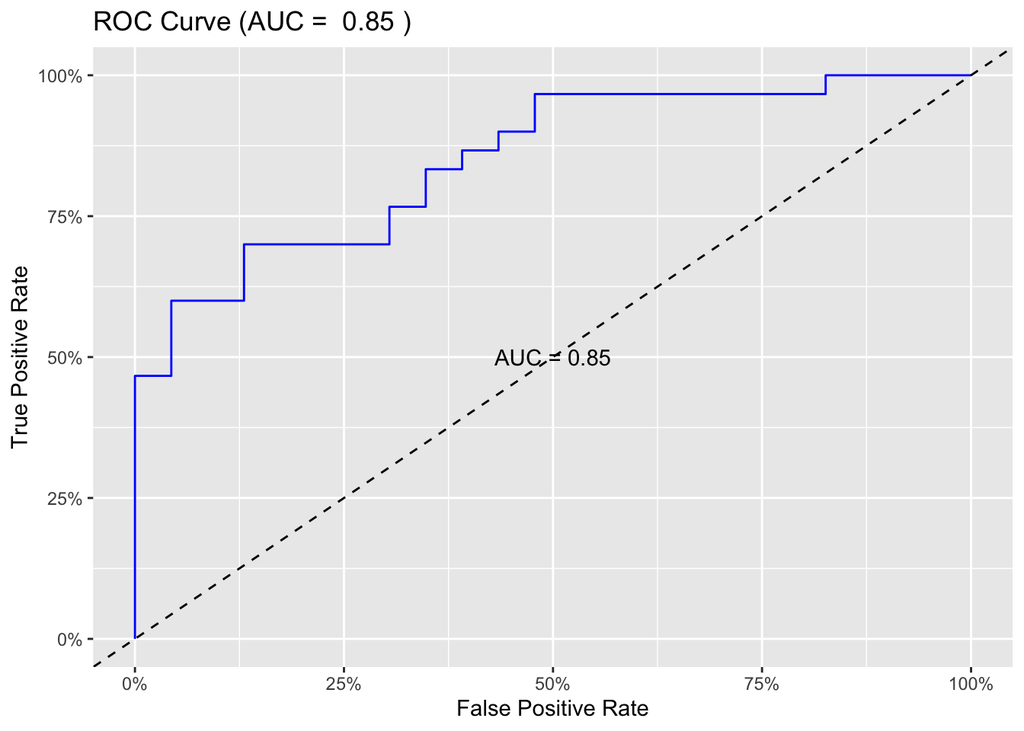

```r
auc_sm <- auc(roc_sm)

ggroc(roc_sm, color = "blue", legacy.axes = TRUE) +
  geom_abline(intercept = 0, slope = 1, linetype = "dashed") +
  scale_x_continuous(labels = scales::percent_format()) +
  scale_y_continuous(labels = scales::percent_format()) +
  labs(x = "False Positive Rate", y = "True Positive Rate",
       title = paste("ROC Curve (AUC = ", round(auc_sm, 2), ")")) +
  annotate("text", x = 0.5, y = 0.5, label = paste0("AUC = ", round(auc_sm, 2)))
```

- AUC of the ROC curve = 85%
- Considering both AUC of the ROC curve of 85% and a precision of 86.7% we can say that the regression model works well and we will be able to predict the if the student is addicted to social media or not based on the variables provided.
- We can now check how the logistic regression for the second approach works.

#### New Dataset

##### Training and Testing

```r
set.seed(123)
split = sample.split(sm_new$Social.Media.Addiction, SplitRatio = 0.70)
train_sm_new = subset(sm_new, split == TRUE)
test_sm_new = subset(sm_new, split == FALSE)

Xtrain_sm_new <- train_sm_new[,1:5]
Ytrain_sm_new <- train_sm_new[,6]

Xtest_sm_new <- test_sm_new[,1:5]
```

- We consider the training and testing data with a 70-30 split.

##### Regression

```r
x_sm_new <- cbind(Xtrain_sm_new,Ytrain_sm_new)
logistic_sm_new <- glm(Ytrain_sm_new ~ ., data = x_sm_new,family='binomial')
summary(logistic_sm_new)
```

```
##
## Call:
## glm(formula = Ytrain_sm_new ~ ., family = "binomial", data = x_sm_new)
##
## Deviance Residuals:
##     Min       1Q   Median       3Q      Max
## -2.7926  -0.8728   0.3926   0.7931   2.3579
##
## Coefficients:
##                                 Estimate Std. Error z value Pr(>|z|)
## (Intercept)                    -0.598714   0.543588  -1.101 0.270718
## WhatsApp                        0.291979   0.098133   2.975 0.002927 **
## Instagram                       0.555039   0.126742   4.379 1.19e-05 ***
## Snapchat                        0.008102   0.174537   0.046 0.962973
## Linkedin                        0.481654   0.127204   3.786 0.000153 ***
## Total.Social.Media.Screen.Time -0.329884   0.099419  -3.318 0.000906 ***
## ---
## Signif. codes:  0 '***' 0.001 '**' 0.01 '*' 0.05 '.' 0.1 ' ' 1
##
## (Dispersion parameter for binomial family taken to be 1)
##
##     Null deviance: 166.46  on 121  degrees of freedom
## Residual deviance: 125.24  on 116  degrees of freedom
## AIC: 137.24
##
## Number of Fisher Scoring iterations: 5
```

- The regression summary shows that we have significant variables that affect the output variable.
- We check the confusion matrix, precision and recall of our regression below.

```r
probabilities_sm3 <- predict(logistic_sm_new, newdata = Xtest_sm_new, type = "response")

predicted_sm3 <- ifelse(probabilities_sm3 > 0.5, "Yes", "No")
actual_sm <- ifelse(test_sm_new$Social.Media.Addiction == 1, "Yes", "No")
dim(predicted_sm3)
```

[output not shown]

```r
confusion_sm3 <- table(predicted_sm3, actual_sm)
confusion_sm3
```

```
##              actual_sm
## predicted_sm3 No Yes
##           No  14   5
##           Yes  9  25
```

```r
accuracy3 <- sum(diag(confusion_sm3)) / sum(confusion_sm3)
precision3 <- confusion_sm3[2, 2] / sum(confusion_sm3[, 2])
recall3 <- confusion_sm3[2, 2] / sum(confusion_sm3[2, ])
cat("Accuracy:", round(accuracy3, 3), "\n")
```

```
## Accuracy: 0.736
```

```r
cat("Precision:", round(precision3, 3), "\n")
```

```
## Precision: 0.833
```

```r
cat("Recall:", round(recall3, 3), "\n")
```

```
## Recall: 0.735
```

```r
roc_sm_new <- roc(test_sm_new$Social.Media.Addiction, probabilities_sm3)
auc_sm_new <- auc(roc_sm_new)
auc_sm_new
```

```
## Area under the curve: 0.8348
```

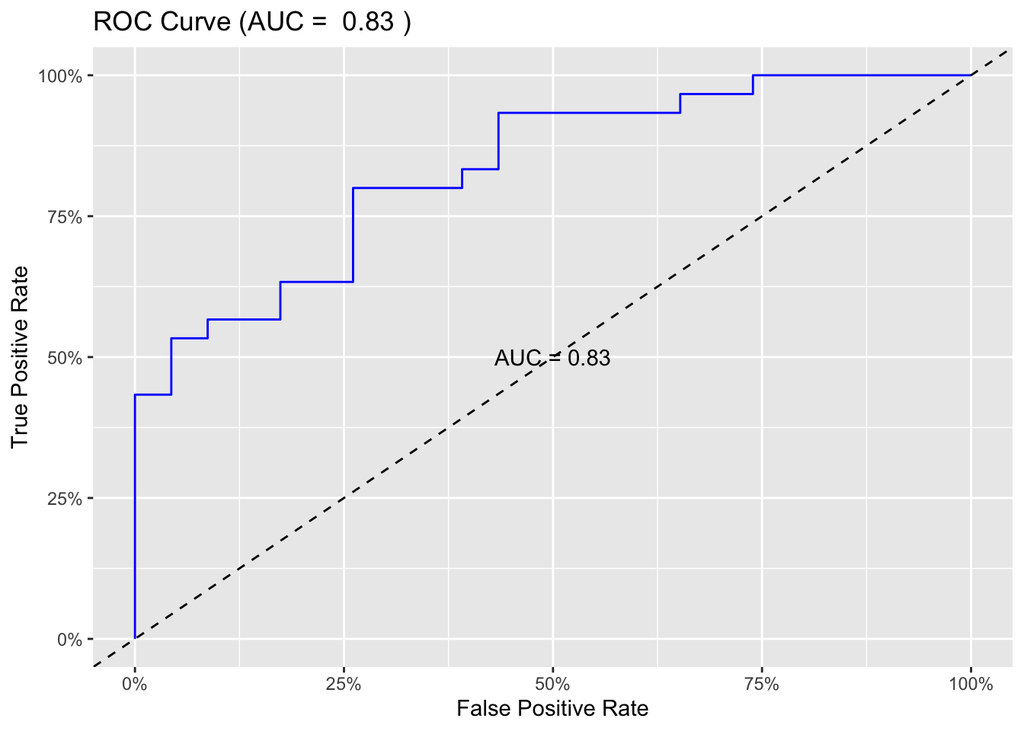

```r
ggroc(roc_sm_new, color = "blue", legacy.axes = TRUE) +
  geom_abline(intercept = 0, slope = 1, linetype = "dashed") +
  scale_x_continuous(labels = scales::percent_format()) +
  scale_y_continuous(labels = scales::percent_format()) +
  labs(x = "False Positive Rate", y = "True Positive Rate",
       title = paste("ROC Curve (AUC = ", round(auc_sm_new, 2), ")")) +
  annotate("text", x = 0.5, y = 0.5, label = paste0("AUC = ", round(auc_sm_new, 2)))
```

## Regression Summary

#### Considering both the approaches, we can see that we can predict if the student is addicted to social media based on the input variables.

#### Answer to our question 2: Yes, we can predict.

#### Our hypothesis that we can predict the addiction can be proved right.